# The Effects of Weather Events for Economy and Population Health in the U.S.

## Data Processing

For data processing and showing the results, two libraries are loaded:

```r
library(ggplot2)
library(stringdist)
```

Loading the data from the compressed csv-file into R:

```r
if(!file.exists("StormData.csv.bz2")) {
        download.file("https://d396qusza40orc.cloudfront.net/repdata%2Fdata%2FStormData.csv.bz2", "StormData.csv.bz2")
}
data <- read.csv("StormData.csv.bz2", stringsAsFactors=FALSE)
```

There are two main functions that are used to clean the data into a more readable format: process_ev() and process_mag().

process_mag()-function is used with the economic damage, where the magnitude of costs is presented.

The function takes data as a parameter, and assumes that there are two columns: First the magnitude (K/M/B) and then the estimated cost. These results are collected into a new dataframe and returned to the caller, removing those data fields (turned in NA) that do not provide the magnitude, or a different magnitude that expected.

The function takes the costs and the magnitude, and multiplies the number of costs appropriately, applying simple conditionals.

```r
process_mag <- function(data) {
    new_data <- data.frame(DMG=numeric())
    for(i in 1:nrow(data)) {
        row <- data[i, ]
        mag <- row[, 1]

        if(mag == "K" | mag == "k") {
            new_data[i, 2] <- row[, 2] * 1000
        }
        else if(mag == "M" | mag == "m") {
            new_data[i, 2] <- row[, 2] * 1000000
        }
        else if(mag == "B" | mag == "b") {
            new_data[i, 2] <- row[, 2] * 1000000000
        }
    }
    new_data
}
```

The second function, process_ev() is more complex. It is used for cleaning the event type classifications from typos and misclassifications.

In the beginning, the actual classifications from the Storm Data Documentation (URL: https://d396qusza40orc.cloudfront.net/repdata%2Fpeer2_doc%2Fpd01016005curr.pdf) are set as a reference set of data. Additionally the names and the data are set as toupper in order to remove issues with capitalization of letters.

The function expects a set of data with two columns, the event type and a sum. Applying a for-loop and functions from base (agrep() and adist()) and a library stringdist (amatch()), the function loops through the given set of data (only the event types) and finds close matches from the classification, but also from the current list of types itself. Finally, the function calculates the new sums based on similar types of strings and returns a cleaner set of data to the caller.

```r
process_ev <- function(data) {
    names <- c("Astronomical Low Tide","Avalanche","Blizzard",
        "Coastal Flood","Cold/Wind Chill","Debris Flow",
        "Dense Fog","Dense Smoke","Drought","Dust Devil",
        "Dust Storm","Excessive Heat","Extreme Cold/Wind Chill",
        "Flash Flood","Flood","Frost/Freeze","Funnel Cloud",
        "Freezing Fog","Hail","Heat","Heavy Rain","Heavy Snow",
        "High Surf","High Wind","Hurricane (Typhoon)","Ice Storm",
        "Lake-Effect Snow","Lakeshore Flood","Lightning",
        "Marine Hail","Marine High Wind","Marine Strong Wind",
        "Marine Thunderstorm Wind","Rip Current","Seiche","Sleet",
        "Storm Surge/Tide","Strong Wind","Thunderstorm Wind","Tornado",
        "Tropical Depression","Tropical Storm","Tsunami","Volcanic Ash",
        "Waterspout","Wildfire","Winter Storm","Winter Weather")

    names <- toupper(names)
    tempnames <- toupper(data$EVTYPE)

    colnames(data) <- c("EVTYPE", "SUM")

    for(i in 1:length(tempnames)) {
        row <- tempnames[i]

        index_names <- agrep(row, names, max.distance = 2, ignore.case=TRUE)
        index_list <- agrep(row, tempnames, max.distance = 2, ignore.case=TRUE)

        if(length(index_names) == 1 & length(index_list) == 1) {
            tempnames[index_list] <- names[index_names]
        }
        else if(length(index_names) == 0 & length(index_list) == 1) {}
        else if(length(index_names) == 2) {
            temp <- names[index_names]

            type <- adist(row, temp, ignore.case=TRUE)
            if(min(type) < 9) {
                index <- which(min(type) == type)
                tempnames[i] <- temp[index]
            }
        }
        else {
            temp <- names[amatch(row, names, maxDist=2, method="lv")]
            if(!is.na(temp)) {tempnames[i] <- temp}
        }

    }
    data$EVTYPE <- tempnames
    aggregate(SUM ~ EVTYPE, data, sum)
}
```

While this method is not perfect and it leaves some anomalies, it is relatively fast and simple method to clean typos, abbreviations, and different ways to write same categorizations, by using the official guide.

Using these two functions, the data is cleaned. First, the appropriate columns are subsetted from the data, taking the sums of total damages per each event type. In ecomonic damages, the magnitude is also a part of the classifiers, in order to divide different magnitudes.

When the relevant data is extracted from the complete set of data, the unnecessary parts of these sets are removed. For health damage, all such reports without any injuries or fatalities are removed. For economic damages, only those fields that have a proper magnitude are taken forward.

Finally, the function to clean and combine the event types is applied for each set. This could have been done for the whole set of data, but because of the high complexity of the function, it was decided to use as the last step, for concatenated sets.

After the event type strings had been concatenated, the ten events with highest sums were selected for the final presentation.

```r
injuries <- aggregate(INJURIES ~ EVTYPE, data, sum)
fatalities <- aggregate(FATALITIES ~ EVTYPE, data, sum)
propdmg <- aggregate(PROPDMG ~ EVTYPE + PROPDMGEXP, data, sum)
cropdmg <- aggregate(CROPDMG ~ EVTYPE + CROPDMGEXP, data, sum)

inj <- injuries[injuries$INJURIES > 0, ]
fats <- fatalities[fatalities$FATALITIES > 0, ]
propdmg[, c(2,3)] <- process_mag(propdmg[, c(2,3)])
cropdmg[, c(2,3)] <- process_mag(cropdmg[, c(2,3)])

temp <- process_ev(inj)
injured <- head(temp[order(temp$SUM, decreasing=T),], 10)

temp <- process_ev(fats)
fatal <- head(temp[order(temp$SUM, decreasing=T),], 10)

temp <- process_ev(propdmg[, c(1,3)])
properties <- head(temp[order(temp$SUM, decreasing=T),], 10)

temp <- process_ev(cropdmg[, c(1,3)])
crops <- head(temp[order(temp$SUM, decreasing=T),], 10)
```

Because the injuries and fatalities had a completely different number of incidents, they were left separate. But the damages for property and crops were in a similar scale and were combined, using rbind() and once more concatenated using aggregate(). The scale was also made into billions for easier representation.

```r
temp <- rbind(properties, crops)
dmgs <- aggregate(SUM ~ EVTYPE, temp, sum)
dmgs$SUM <- dmgs$SUM / 1000000000
```

## Results

The results are divided into two parts, as per the research questions. First, the incidents that affected population health are shown, followed by the economic costs of incidents.

#### Health damage

The incidents that affected population health are divided into injuries and fatalities. In Figure 1. the number of injuries caused by weather events are shown. As can be seen from the Figure, the highest number of injuries is caused by tornadoes, where the number is closer to 100 000 injuries. The other incidents that injure are thunderstorm winds, floods, excessive heat, and lightning, but their numbers are under 10 000 incidents

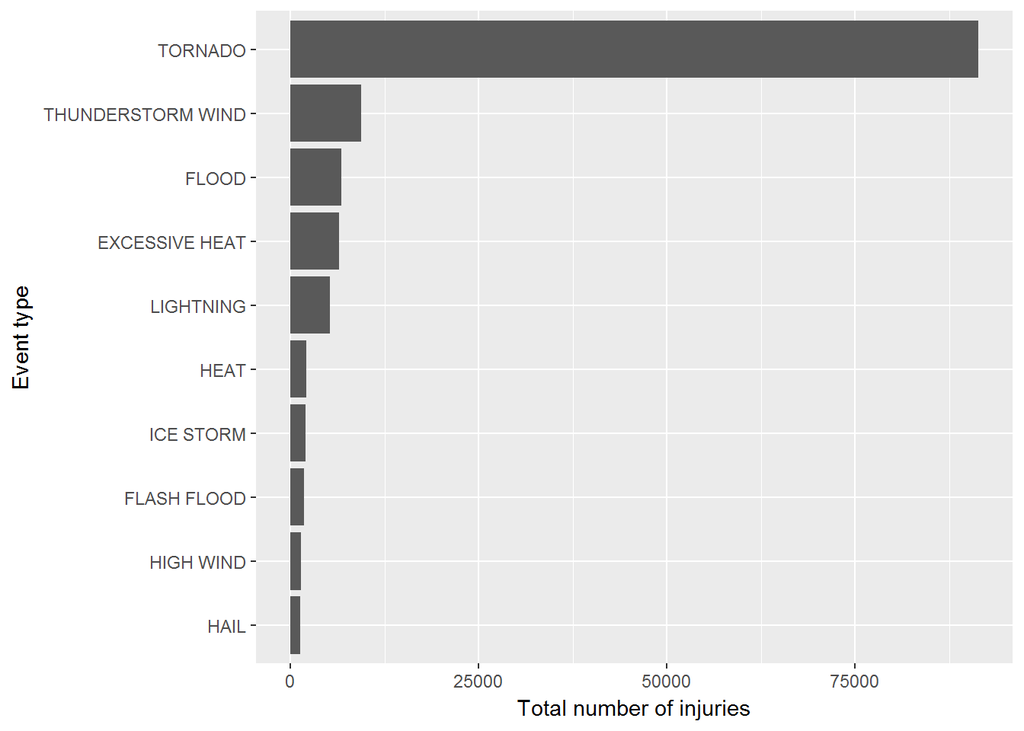

```r
ggplot(injured, aes(x=reorder(EVTYPE, SUM), y=SUM)) +
        geom_bar(stat="identity") +
        coord_flip() +
        xlab("Event type") + ylab("Total number of injuries")
```

Figure 1. Injuries per weather event

Fatalities are excessively more rare than injuries when weather events are concerned, and thus the difference between the weather types is smaller. In Figure 2. the number of fatalities per weather event is presented. While the magnitude is smaller, tornadoes are still the biggest cause of fatalities. Other significant causes are heat, flash floods, and lightning.

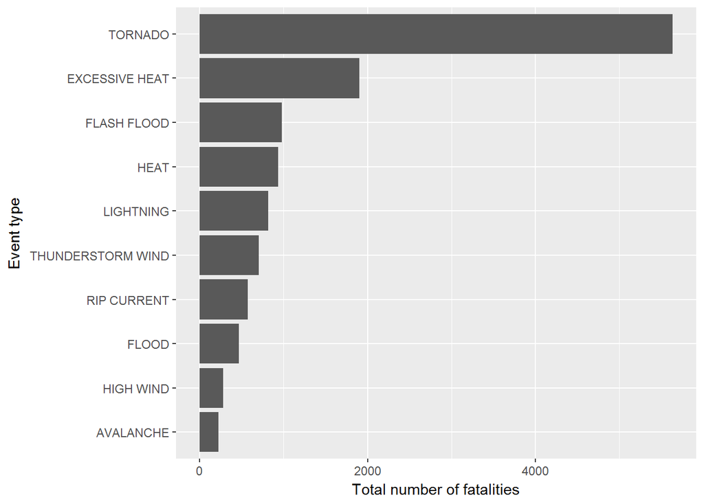

```r
ggplot(fatal, aes(x=reorder(EVTYPE, SUM), y=SUM)) +
        geom_bar(stat="identity") +
        coord_flip() +
        xlab("Event type") + ylab("Total number of fatalities")
```

Figure 2. Fatalities per weather event

As a summary, these results would indicate that a large number of injuries and fatalities are due to tornadoes. The other types of dangerous weather events, that need to be prepared for, are thunderstorms with lightning, heat, and flooding.

#### Property damage

When compared to the health damages, the economic damages have a more versatile set of causes, presented in Figure 3. For economic damages, the damages towards property and the damages towards crops are combined. The highest amount of costs from from floods, around 150 billion dollars. Other significantly separated group is hurricanes, tornadoes, and storm surges. Other issues come from storms, hail, and drought.

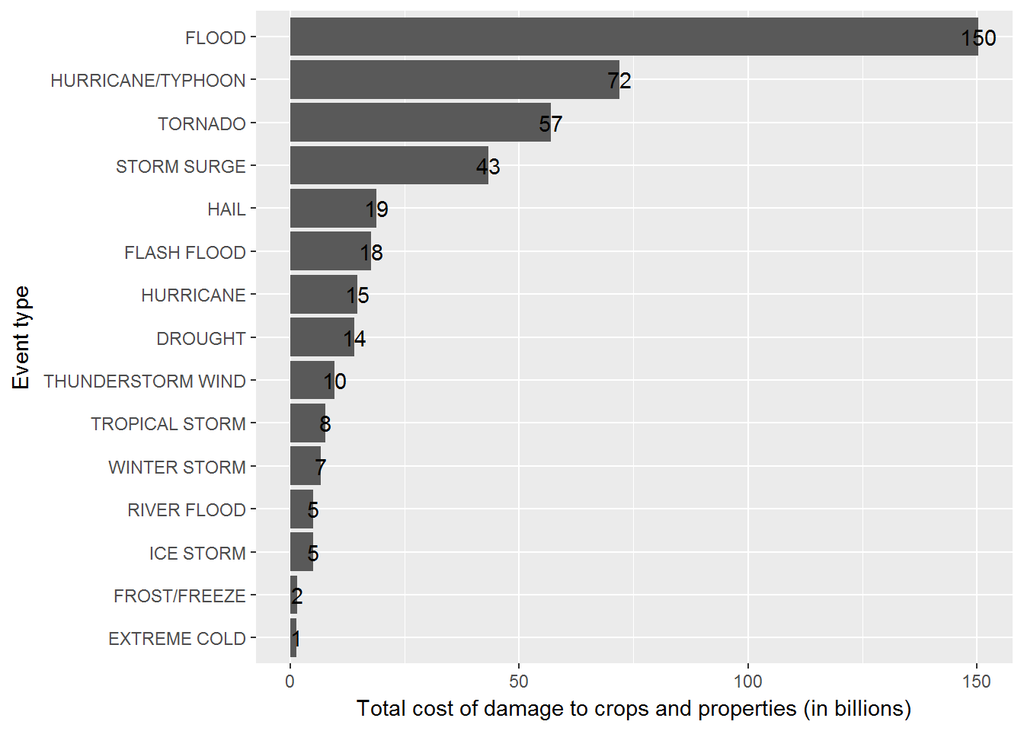

```r
ggplot(dmgs, aes(x=reorder(EVTYPE, SUM), y=SUM)) +
        geom_bar(stat="identity") +
        coord_flip() +
        xlab("Event type") +
        ylab("Total cost of damage to crops and properties (in billions)") +
        geom_text(aes(label=round(SUM)))
```

Figure 3. Economic damages per weather event